# Bay of Biscay and the Iberian Coast

#### Figure 2

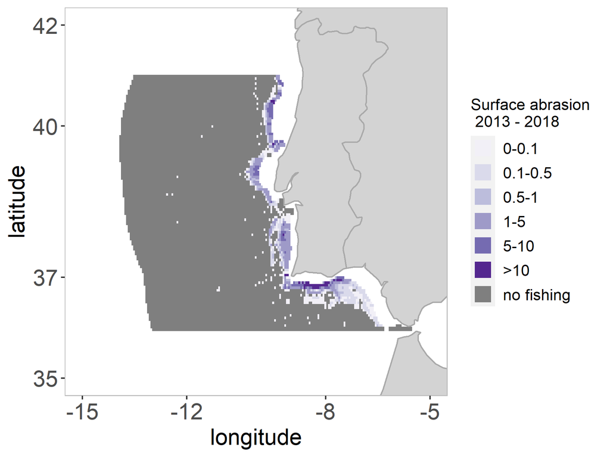

**Figure 2 Surface abrasion, Swept Area Ratio, by mobile bottom-contacting gears (year-1), averaged for the 2013-2018 six-year cycle**

#### Table 2

Table 2 Overview of pressure indicators of all mobile bottom-contacting gears per broad-scale habitat averaged for 2013-2018. I refers to the indicators in Table 1.

| MSFD broad habitat type | Extent of habitat (1000 km<sup>2</sup>) | Number of grid cells | Landings 1000 tonnes | Value 10<sup>6</sup> euro | Swept area 1000 km<sup>2</sup> | Average intensity (I-1) | Prop. of area in fished grid cells (I-2) | Prop. of area fished per year (I-3) | Smallest prop. of area with 90% of fishing effort (I-4) |
| --- | --- | --- | --- | --- | --- | --- | --- | --- | --- |
| Upper bathyal sediment | 11.74 | 689 | NA | NA | 18.78 | 1.60 | 0.65 | 0.37 | 0.23 |
| Upper bathyal sediment or Upper bathyal rock and biogenic reef | 15.96 | 955 | NA | NA | 10.02 | 0.63 | 0.47 | 0.21 | 0.14 |
| Offshore circalittoral mud | 1.33 | 168 | NA | NA | 6.27 | 4.71 | 0.91 | 0.72 | 0.29 |
| Lower bathyal sediment or Lower bathyal rock and biogenic reef | 14.98 | 1051 | NA | NA | 0.52 | 0.04 | 0.13 | 0.02 | 0.03 |
| Offshore circalittoral sand | 0.32 | 65 | NA | NA | 0.43 | 1.35 | 0.59 | 0.36 | 0.23 |
| Upper bathyal rock and biogenic reef | 0.42 | 142 | NA | NA | 0.41 | 0.96 | 0.59 | 0.35 | 0.18 |
| Offshore circalittoral rock and biogenic reef | 0.15 | 76 | NA | NA | 0.26 | 1.67 | 0.75 | 0.56 | 0.30 |
| Offshore circalittoral mixed sediment | 0.06 | 36 | NA | NA | 0.25 | 3.98 | 0.99 | 0.83 | 0.33 |
| Abyssal | 184.55 | 7854 | NA | NA | 0.03 | 0.00 | 0.01 | 0.00 | 0.00 |
| Unknown | 0.15 | 26 | NA | NA | 0.02 | 0.12 | 0.19 | 0.03 | 0.08 |
| Lower bathyal sediment | 0.04 | 16 | NA | NA | 0.01 | 0.17 | 0.58 | 0.17 | NA |
| Offshore circalittoral coarse sediment | 0.01 | 7 | NA | NA | 0.00 | 0.33 | 0.56 | 0.33 | NA |
| Circalittoral rock and biogenic reef | 0.01 | 11 | NA | NA | 0.00 | 0.01 | 0.43 | 0.01 | NA |
| Infralittoral rock and biogenic reef | 0.00 | 4 | NA | NA | 0.00 | 0.02 | 0.68 | 0.02 | NA |
| Circalittoral mixed sediment | 0.00 | 3 | NA | NA | 0.00 | 0.00 | 0.00 | 0.00 | NA |
| Circalittoral mud | 0.00 | 3 | NA | NA | 0.00 | 0.00 | 0.00 | 0.00 | NA |
| Circalittoral sand | 0.00 | 5 | NA | NA | 0.00 | 0.00 | 0.00 | 0.00 | NA |
| Infralittoral sand | 0.00 | 2 | NA | NA | 0.00 | 0.00 | 0.00 | 0.00 | NA |

#### Figure 3

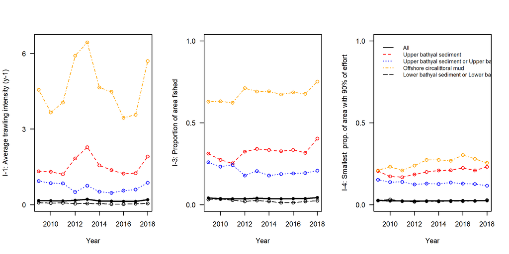

**Figure 3. Time series of (a) mean fishing intensity (surface abrasion), (b) proportion of the surface area of the seafloor fished, (c) aggregation of fishing (proportion of the surface area with 90% of the fishing effort) by habitat. Results represent vessels over 15m (2009-2011) and vessels over 12m (2012-2018).**

#### Figure 4

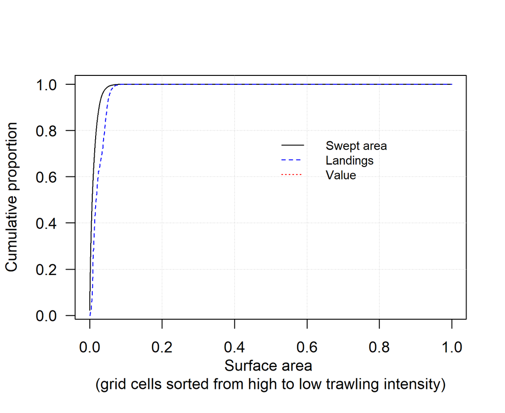

**Figure 4. Cumulative proportion of the swept area, landings and value. Grid cells were sorted from highest to lowest fishing intensity and include non-fished cells. The results are for all mobile bottom-contacting gears based on averaged fishing data per c-square from 2013-2018.**

### Core fishing grounds

No information available

### Fishing by métier

Area swept is estimated for the grid cells that were fished by one MBCG métier, ignoring cells fished by other métiers (Table 3).

#### Table 3

Table 3. Overview of area fished (sum of swept area), landings and value for the different metiers. Area fished in 1000 km2, weight of landings in 1000 tonnes, value of landings in 10^6 euro.

|  | DRB_MOL | OT_CRU | OT_DMF | OT_MI | OT_SPF | SDN_DMF | SSC_DMF | TBB_CRU | TBB_DMF | TBB_MOL |
| --- | --- | --- | --- | --- | --- | --- | --- | --- | --- | --- |
| Area swept (1000 km2) | <0.005 | 33.22 | 3.78 | 0 | 0 | 0 | 0 | 0 | 0 | 0 |
| Landings (1000 tonnes) | NA | NA | NA | NA | NA | NA | NA | NA | NA | NA |
| Value (10^6 euro) | NA | NA | NA | NA | NA | NA | NA | NA | NA | NA |
| Landings (1000 tonnes)/Area swept (1000 km2) | NA | NA | NA | NA | NA | NA | NA | NA | NA | NA |
| Value (10^6 euro)/Area swept (1000 km2) | NA | NA | NA | NA | NA | NA | NA | NA | NA | NA |

### Impact

No information available

### Management scenarios

No information available on value/weight of landings.

#### Overview all MSFD habitats

Fishing effort consequences, as a % relative to total swept area, of protecting a certain fraction of each broad habitat type sorted from low to high fished c-squares

| MSFD broad habitat type | Extent of habitat 1000 km<sup>2</sup> | 0.05 | 0.1 | 0.2 | 0.3 | 0.4 | 0.5 | 0.6 | 0.7 | 0.8 | 0.9 |
| --- | --- | --- | --- | --- | --- | --- | --- | --- | --- | --- | --- |
| Upper bathyal sediment | 11.74 | 0.0 | 0.0 | 0.0 | 0.0 | <0.1 | 0.5 | 1.7 | 5.4 | 16.6 | 40.7 |
| Upper bathyal sediment or Upper bathyal rock and biogenic reef | 15.96 | 0.0 | 0.0 | 0.0 | 0.0 | 0.0 | 0.0 | 0.2 | 1.0 | 5.6 | 22.3 |
| Offshore circalittoral mud | 1.33 | 0.0 | <0.1 | 0.5 | 1.6 | 4.1 | 9.6 | 19.6 | 30.1 | 42.6 | 63.5 |
| Lower bathyal sediment or Lower bathyal rock and biogenic reef | 14.98 | 0.0 | 0.0 | 0.0 | 0.0 | 0.0 | 0.0 | 0.0 | 0.0 | 0.0 | 1.6 |
| Offshore circalittoral sand | 0.32 | 0.0 | 0.0 | 0.0 | 0.0 | 0.0 | 1.6 | 4.9 | 12.4 | 22.4 | 64.9 |
| Upper bathyal rock and biogenic reef | 0.42 | 0.0 | 0.0 | 0.0 | 0.0 | 0.0 | 0.5 | 4.4 | 10.6 | 29.7 | 72.8 |
| Offshore circalittoral rock and biogenic reef | 0.15 | 0.0 | 0.0 | 0.0 | 0.2 | 2.4 | 10.1 | 17.8 | 32.1 | 42.3 | 73.0 |
| Offshore circalittoral mixed sediment | 0.06 | 0.2 | 0.9 | 2.5 | 5.5 | 11.2 | 19.5 | 21.9 | 33.3 | 42.2 | 59.3 |
| Abyssal | 184.55 | 0.0 | 0.0 | 0.0 | 0.0 | 0.0 | 0.0 | 0.0 | 0.0 | 0.0 | 0.0 |
| Unknown | 0.15 | 0.0 | 0.0 | 0.0 | 0.0 | 0.0 | 0.0 | 0.0 | 0.0 | 0.0 | 5.0 |
| Lower bathyal sediment | 0.04 | 0.0 | 0.0 | 0.0 | 0.0 | 0.0 | 47.7 | 47.7 | 47.7 | 47.7 | 100.0 |
| Offshore circalittoral coarse sediment | 0.01 | 0.0 | 0.0 | 0.0 | 0.0 | 0.0 | 35.3 | 35.3 | 100.0 | 100.0 | 100.0 |
| Circalittoral rock and biogenic reef | 0.01 | 0.0 | 0.0 | 0.0 | 0.0 | 0.0 | 0.0 | 100.0 | 100.0 | 100.0 | 100.0 |
| Infralittoral rock and biogenic reef | 0 | 0.0 | 0.0 | 0.0 | 0.0 | 100.0 | 100.0 | 100.0 | 100.0 | 100.0 | 100.0 |
| Circalittoral mixed sediment | 0 | 0.0 | 0.0 | 0.0 | 0.0 | 0.0 | 0.0 | 0.0 | 0.0 | 0.0 | 0.0 |
| Circalittoral mud | 0 | NaN | NaN | NaN | NaN | NaN | NaN | NaN | NaN | NaN | NaN |
| Circalittoral sand | 0 | NaN | NaN | NaN | NaN | NaN | NaN | NaN | NaN | NaN | NaN |
| Infralittoral sand | 0 | NaN | NaN | NaN | NaN | NaN | NaN | NaN | NaN | NaN | NaN |

## Read me

**Assessment sheet for Bay of Biscay and the Iberian Coast sub-region and for six subdivisions**

WKTRADE3 developed an assessment of fishing footprint of mobile bottom-contacting fishing gears (MBCG) and benthic impact that is appropriate for a six-year management cycle of MSFD assessments. The assessment maps and pressure and impact indicator values produced are based on an average fishing intensity of 2013-2018. This assessment period is linked to the latest available fishing data, rather than to the MSFD Art 8 assessment periods. The assessment product further shows year-to-year variation in pressure and impact from 2009.

Table 1. Pressure and impact indicators that are applied by (sub-)regional, subdivision sea, or broadscale habitat type within that sea at a 0.05° × 0.05° grid, hereafter termed c-square.

[output not shown]

**Data limitations in Bay of Biscay and the Iberian Coast sub-region**

Temporal patterns in fishing activity are available from 2009 for vessels over 15m and from 2012 for vessels over 12m. Temporal variation in fishing activity hence represents vessels over 15m (2009-2011) and vessels over 12m (2012-2018). The assessment maps and indicator values produced are based on an average for 2013-2018.

**How are changes in the fishing footprint analyzed?**

To describe the fishing footprint, we expressed fishing intensity as swept-area ratios (SAR). The swept area is calculated as hours fished x average fishing speed x gear width. The gear width is estimated based on relationships between average gear widths and average vessel length or engine power (kW), as stated in Eigaard et al. (2016) and using ICES expert input. The swept-area ratio is the sum of the swept area divided by the area of each grid cell (c-square). Therefore, the C-square SAR value indicates the theoretical number of times the entire grid cell has been swept if effort was evenly distributed within the cell. For example, a SAR of 2 means that each location within the c-square is fished 2 times over the year, a SAR of 0.5 means that each location within the c-square is fished once in two years. Due to data availability, all analyses of the fishing footprint do not account for sub-grid variation of fishing events within the c-square.

In order to better understand the relationship between catch/value of landings and the levels of physical disturbance for MSFD purposes, the analysis considers ten gear groupings (hereafter termed métiers) together with the total intensity of all gears (Table 2).

Table 2 Gear groupings used in the analysis. Note that OT_CRU includes OT_MIX_CRU and OT_MIX_CRU_DMF, and, OT_MIX includes OT_MIX_DMF_BEN and OT_MIX_DMF_PEL.

| Métier | Main.gear.type | Target.species.assemblage.group | Main.target.species | Depletion.rate |
| --- | --- | --- | --- | --- |
| DRB_MOL | Dredge | Molluscs | Scallops | 0.200 |
| OT_CRU | Otter trawl | Crustaceans | Nephrops, Pandalus, mixed fish | 0.100 |
| OT_DMF | Otter trawl | Demersal fish | Cod or plaice | 0.026 |
| OT_MIX | Otter trawl | Mixed fish | Mixed fish | 0.074 |
| OT_SPF | Otter trawl | Small pelagic fish | Sprat or sandeel | 0.009 |
| SDN_DMF | Danish seine | Demersal fish | Plaice, cod | 0.009 |
| SSC_DMF | Flyshooter (seine) | Demersal fish | Cod, haddock, flatfish | 0.016 |
| TBB_CRU | Beam trawl | Crustaceans | Brown shrimp | 0.060 |
| TBB_DMF | Beam trawl | Demersal fish | Flatfish | 0.140 |
| TBB_MOL | Beam trawl | Molluscs | Whelk, snails and scallops | 0.060 |

**How is benthic impact evaluated?**

No prediction of benthic community longevity is available and no benthic impact is estimated.

**References**

Eigaard O.R., Bastardie F., Breen M.l., Dinesen G.E., Lafargue P., Nielsen J.R., Nilson H., O’Neil F., Polet H., Reid D., Sala A., Sköld M., Smith C., Sørensen T.K., Tully O., Zengin M., Hintzen N.T., Rijnsdorp A.D. (2016). Estimating seafloor pressure from trawls and dredges based on gear design and dimensions. ICES J. Mar. Sci. 73(1): 27-43 https://doi.org/10.1093/icesjms/fsv099

ICES 2017. EU request on indicators of the pressure and impact of bottom-contacting fishing gear on the seabed, and of trade-offs in the catch and the value of landings. ICES Special Request Advice, eu.2017.13. 27 pp. https://doi.org/10.17895/ices.advice.5657.